# p2_and_p3_mid_term

Gurdeep

25/10/2020

```r
rm(list = ls())

setwd("/cloud/project/HW//mid_term_real") # change to local directory before running

library(knitr)
library(onewaytests)
library(olsrr)
library(lmtest)
library(MASS)
library(ALSM)
```

P2

Read in dataset for problem 2

```r
# read in the data set
p2 <- read.csv('Midterm Q2 Data Set.csv')
head(p2)
```

```
##    Y X1    X2  X3  X4   X5     X6
## 1 58 23 25.09 346 0.6  0.6   1.84
## 2 31 21  1.24 109 0.6 26.3 572.33
## 3  3  3  0.21 114 2.8 58.7   0.78
## 4 25  9  0.10  46 1.9 47.4   0.18
## 5  2  1  0.05  77 1.9  1.9 903.82
## 6 18 11  0.34 119 8.0  8.0   1.84
```

```r
colnames(p2)
```

```
## [1] "Y"  "X1" "X2" "X3" "X4" "X5" "X6"
```

```r
dim(p2)
```

```
## [1] 30  7
```

Perform one factor analysis by finding the best variable to explain Y. Fit one variable regression model with Y as a dependent variable against remaining variables, as an independent variable one at a time.

After reading in the dataset we perform 1 factor analysis below

```r
reg_p2_r2 <- vector(mode = 'integer', length = (ncol(p2)-1))

for (i in 2:(ncol(p2))) {
  print(paste("Regression with x",i-1))
  #print(p2[1,i])
  reg <- lm(Y~p2[,i], data = p2)
  print(summary(reg))
  reg_p2_r2[i-1] <- summary(reg)$r.squared
}
```

```
## [1] "Regression with x 1"
##
## Call:
## lm(formula = Y ~ p2[, i], data = p2)
##
## Residuals:
##     Min      1Q  Median      3Q     Max
## -71.791 -15.894   3.507  12.088  78.200
##
## Coefficients:
##             Estimate Std. Error t value Pr(>|t|)
## (Intercept) -21.0480     7.1138  -2.959  0.00622 **
## p2[, i]       4.0721     0.1899  21.443  < 2e-16 ***
## ---
## Signif. codes:  0 '***' 0.001 '**' 0.01 '*' 0.05 '.' 0.1 ' ' 1
##
## Residual standard error: 27.95 on 28 degrees of freedom
## Multiple R-squared:  0.9426, Adjusted R-squared:  0.9406
## F-statistic: 459.8 on 1 and 28 DF,  p-value: < 2.2e-16
##
## [1] "Regression with x 2"
##
## Call:
## lm(formula = Y ~ p2[, i], data = p2)
##
## Residuals:
##     Min      1Q  Median      3Q     Max
## -99.495 -53.431 -29.045   3.423 306.137
##
## Coefficients:
##             Estimate Std. Error t value Pr(>|t|)
## (Intercept) 63.78286   17.52442   3.640 0.001094 **
## p2[, i]      0.08196    0.01971   4.158 0.000275 ***
## ---
## Signif. codes:  0 '***' 0.001 '**' 0.01 '*' 0.05 '.' 0.1 ' ' 1
##
## Residual standard error: 91.73 on 28 degrees of freedom
## Multiple R-squared:  0.3817, Adjusted R-squared:  0.3596
## F-statistic: 17.29 on 1 and 28 DF,  p-value: 0.0002748
##
```

[output cut: 64 more lines]

```
##
## Residuals:
##    Min     1Q Median     3Q    Max
## -85.46 -71.41 -42.60   7.62 359.67
##
## Coefficients:
##             Estimate Std. Error t value Pr(>|t|)
## (Intercept) 84.32743   22.27411   3.786 0.000744 ***
## p2[, i]      0.00347    0.02505   0.139 0.890831
## ---
## Signif. codes:  0 '***' 0.001 '**' 0.01 '*' 0.05 '.' 0.1 ' ' 1
##
## Residual standard error: 116.6 on 28 degrees of freedom
## Multiple R-squared:  0.0006847,  Adjusted R-squared:  -0.03501
## F-statistic: 0.01918 on 1 and 28 DF,  p-value: 0.8908
```

Choose the variable with highest R2 that explains Y

```r
# print out all R2 values and index of max R2
reg_p2_r2
```

```
## [1] 0.9426012084 0.3817300579 0.5453625424 0.0001986427 0.0292897354
## [6] 0.0006846781
```

```r
which.max(reg_p2_r2)
```

```
## [1] 1
```

From the above we see that x1 has the highest R2 that explains Y. Hence we perfrom regression and comment on plots below.

Comment on the QQ plot and error vs. fitted values graph for the model assumptions.

```r
# perform regression
reg_p2 <- lm(p2$Y~p2$X1)
summary(reg_p2)
```

```
##
## Call:
## lm(formula = p2$Y ~ p2$X1)
##
## Residuals:
##     Min      1Q  Median      3Q     Max
## -71.791 -15.894   3.507  12.088  78.200
##
## Coefficients:
##             Estimate Std. Error t value Pr(>|t|)
## (Intercept) -21.0480     7.1138  -2.959  0.00622 **
## p2$X1         4.0721     0.1899  21.443  < 2e-16 ***
## ---
## Signif. codes:  0 '***' 0.001 '**' 0.01 '*' 0.05 '.' 0.1 ' ' 1
##
## Residual standard error: 27.95 on 28 degrees of freedom
## Multiple R-squared:  0.9426, Adjusted R-squared:  0.9406
## F-statistic: 459.8 on 1 and 28 DF,  p-value: < 2.2e-16
```

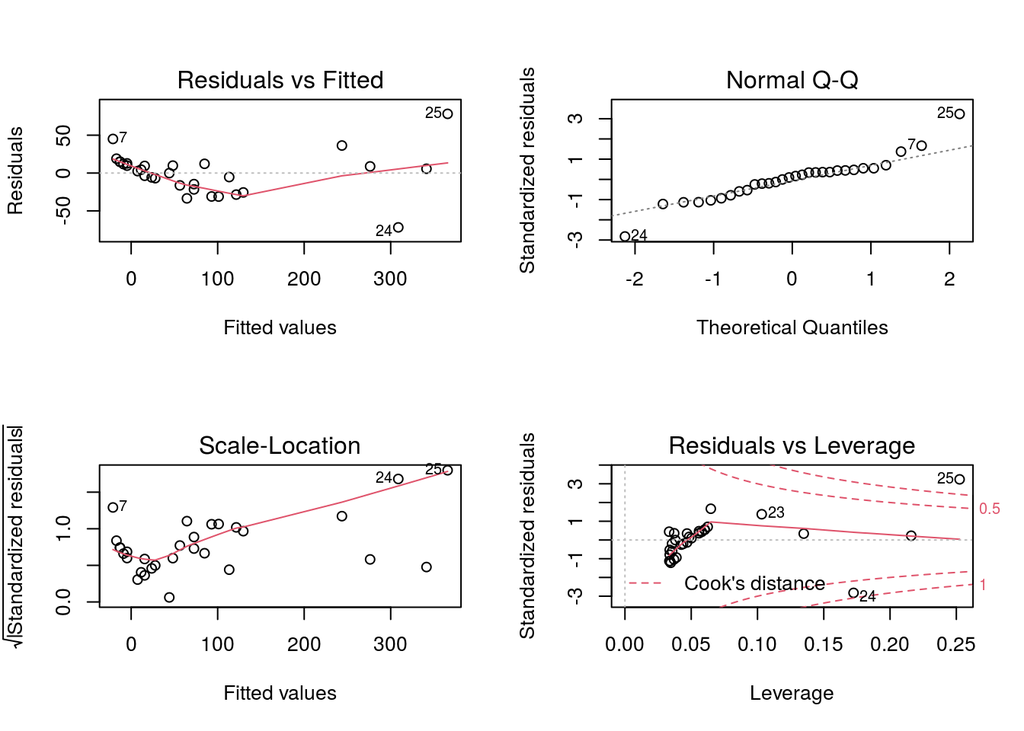

```r
ei_reg_p2 <- reg_p2$residuals

# plot residuals and other standard plots
old.par <- par(mfrow = c(2,2))
plot(reg_p2)
```

```r
old.par
```

```
## $mfrow
## [1] 1 1
```

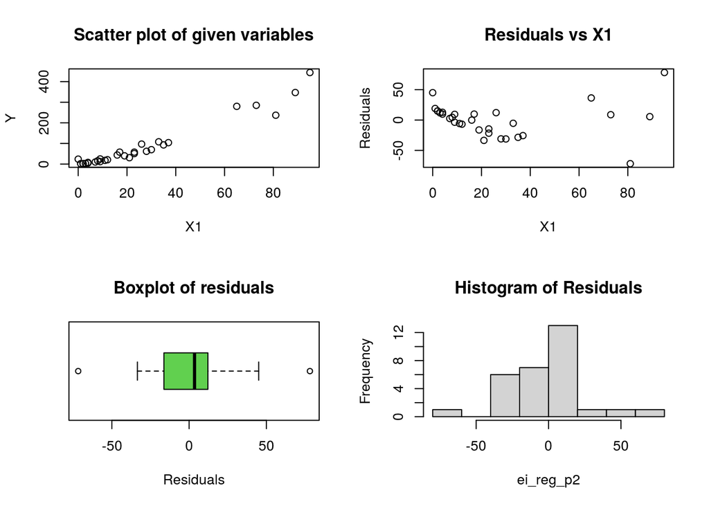

```r
newer.par = par(mfrow = c(2,2))
plot(p2$X1, p2$Y, xlab = 'X1', ylab = 'Y', main = 'Scatter plot of given variables')
plot(p2$X1,ei_reg_p2, xlab = 'X1', ylab = 'Residuals', main = 'Residuals vs X1')
boxplot(ei_reg_p2, horizontal = TRUE, staplewax = 0.5, col = 3, xlab = 'Residuals', main = 'Boxplot of residuals')
hist(ei_reg_p2, main = 'Histogram of Residuals')
```

```r
newer.par
```

```
## $mfrow
## [1] 2 2
```

From the Regression plots we see that

Residuals vs fitted values plot:

1. Shows a downward and an upward trend
2. There are outliers present

Q-Q plot

1. The line is not 45 degrees
2. values start diverging after 1SD on positive and negative sides

Scatterplot of x & y

1. Shows a non-linear relationship; low angle trend which turns upwards

Residuals vs X plot

1. Shows a curved relationship; downward trend and an upward trend; not random

Boxplot

1. Asymmetrical with few outliers

Histogram of residuals 1. Is not normally distributed.

This shows us that the following regression assumptions are not satisfied

1. Linearity of the regression function
2. Error terms have constant variance
3. Error terms are normally distributed
4. Error terms are independent
5. Model fits all but 1 or few outliers

P3

Based on your final model selected on problem 2 (20 points).

a-) is the linear fit appropriate? If not, transform the data and find an appropriate fit. Comment on the model and regression model assumptions. (10 points)

From p2 above we see that a linear fit is not appropriate. The values are spaced into 2 groups and the regression assumptions are also not satisfied.

We use boxcox transform to determine appropriate transform of y since linear regression assumptions are not satisfied.

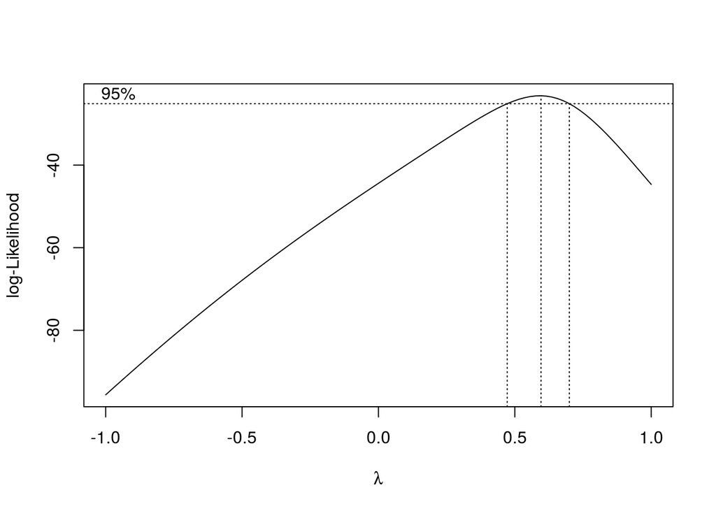

```r
# use the boxcox transformation
boxcox(reg_p2, lambda = seq(-1.0, 1.0,0.1))
```

From the boxcox transformation above we see that the recommended lambda value is closest to 0.5. It is easier to explain lambda = 0.5 which implies a square root transform of the y variable. Below we perform the same and redo regression and plots.

```r
# perform regression
y <- p2$Y
x <- p2$X1
reg_p3a <- lm(sqrt(y)~x)
summary(reg_p3a)
```

```
##
## Call:
## lm(formula = sqrt(y) ~ x)
##
## Residuals:
##      Min       1Q   Median       3Q      Max
## -2.74682 -0.93860  0.01647  0.64009  2.39315
##
## Coefficients:
##             Estimate Std. Error t value Pr(>|t|)
## (Intercept) 2.505832   0.313294   7.998 1.04e-08 ***
## x           0.193034   0.008363  23.081  < 2e-16 ***
## ---
## Signif. codes:  0 '***' 0.001 '**' 0.01 '*' 0.05 '.' 0.1 ' ' 1
##
## Residual standard error: 1.231 on 28 degrees of freedom
## Multiple R-squared:  0.9501, Adjusted R-squared:  0.9483
## F-statistic: 532.7 on 1 and 28 DF,  p-value: < 2.2e-16
```

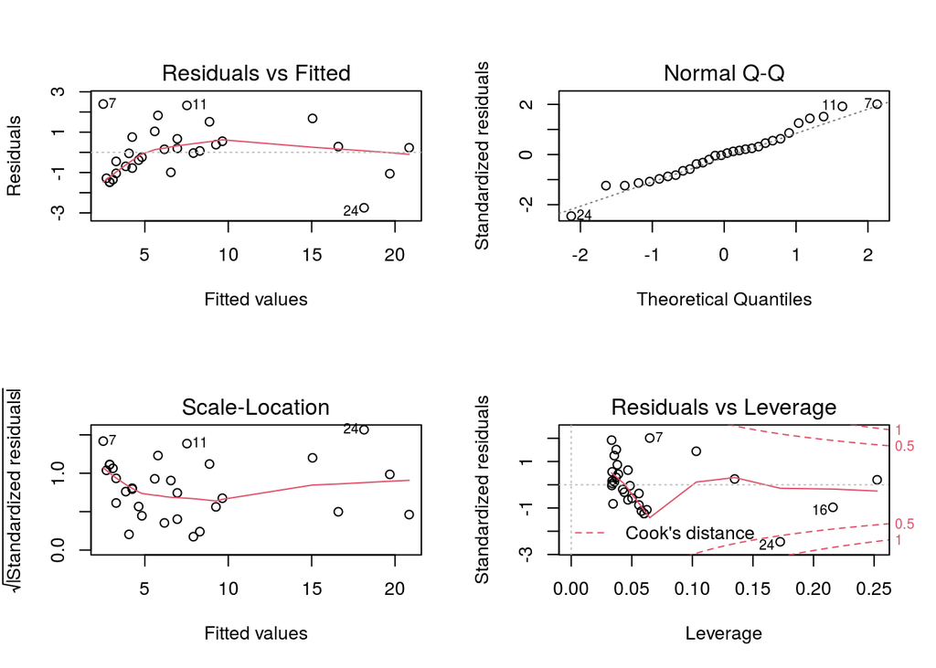

```r
ei_reg_p3a <- reg_p3a$residuals

# plot residuals and other standard plots
old.par <- par(mfrow = c(2,2))
plot(reg_p3a)
```

```r
old.par
```

```
## $mfrow
## [1] 1 1
```

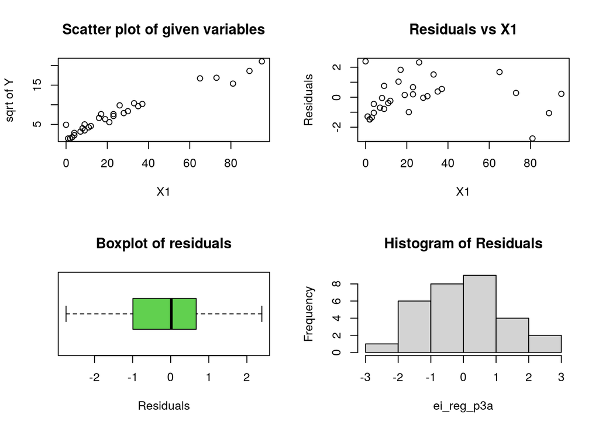

```r
newer.par = par(mfrow = c(2,2))
plot(x, sqrt(y), xlab = 'X1', ylab = 'sqrt of Y', main = 'Scatter plot of given variables')
plot(x,ei_reg_p3a, xlab = 'X1', ylab = 'Residuals', main = 'Residuals vs X1')
boxplot(ei_reg_p3a, horizontal = TRUE, staplewax = 0.5, col = 3, xlab = 'Residuals', main = 'Boxplot of residuals')
hist(ei_reg_p3a, main = 'Histogram of Residuals')
```

```r
newer.par
```

```
## $mfrow
## [1] 2 2
```

From the Regression plots we see that

Q-Q plot 1. The line is at 45 degrees 2. values diverge only slightly after 1SD on positive and negative sides

Scatterplot of x & y 1. Shows a linear relationship

Boxplot 1. Symmetrical with no outliers

Histogram of residuals 1. Is normally distributed.

This shows us that the following regression assumptions are now satisfied

b-)Predict Y when X1=33, X2=18, X3=450, X4=11, X5=12, X6=0.05 and calculate the 99% confidence interval (10 points)

```r
# xh<-data.frame(size=c(30,65,100))

xh <- data.frame(x = c(33, 18, 450, 11, 12, 0.05))
pred_xh <- predict(reg_p3a, xh, se.fit = TRUE, interval = 'confidence', level = 0.99)

# reversing square root transform of y
y_pred <- pred_xh$fit^2
y_pred
```

```
##          fit         lwr        upr
## 1   78.78284   67.812243   90.57558
## 2   35.76581   28.428607   43.94440
## 3 7987.23686 6329.055571 9838.12511
## 4   21.42960   15.341924   28.53212
## 5   23.25406   16.982171   30.50959
## 6    6.32766    2.724395   11.42706
```